# Donor Profile: Switzerland (Government of)

## Focus Portfolio

Switzerland’s 2025 funding portfolio reveals a pronounced funding concentration, with individual allocations ranging dramatically from $5,734 to $7.3 million and a median of $761,432. This 471% variance signals critical opportunity to optimize resource distribution by targeting underfunded regions that currently receive below the 25th percentile threshold of $184,319. Strategic investment in these gaps promises high impact multipliers, amplifying emergency response and resilience-building initiatives aligned with donor priorities. Moreover, the large standard deviation of $1.9 million identifies areas where leveraging Switzerland’s funding strength can unlock partnership potential, enabling scalable innovation and improved accountability. Decision-makers should prioritize tailored engagement strategies to balance portfolio equity and maximize returns on investment. Accelerating targeted donor outreach in regions with suboptimal funding will strengthen organizational agility against emerging risks and unlock untapped programmatic value. Immediate executive action to realign the funding portfolio will transform funding diversity into a powerful strategic lever for sustainable impact.

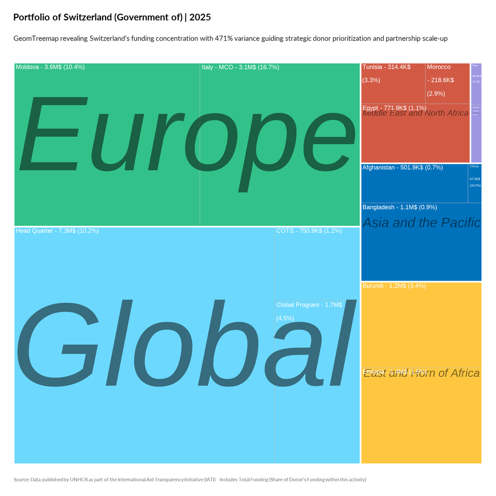

TRUE

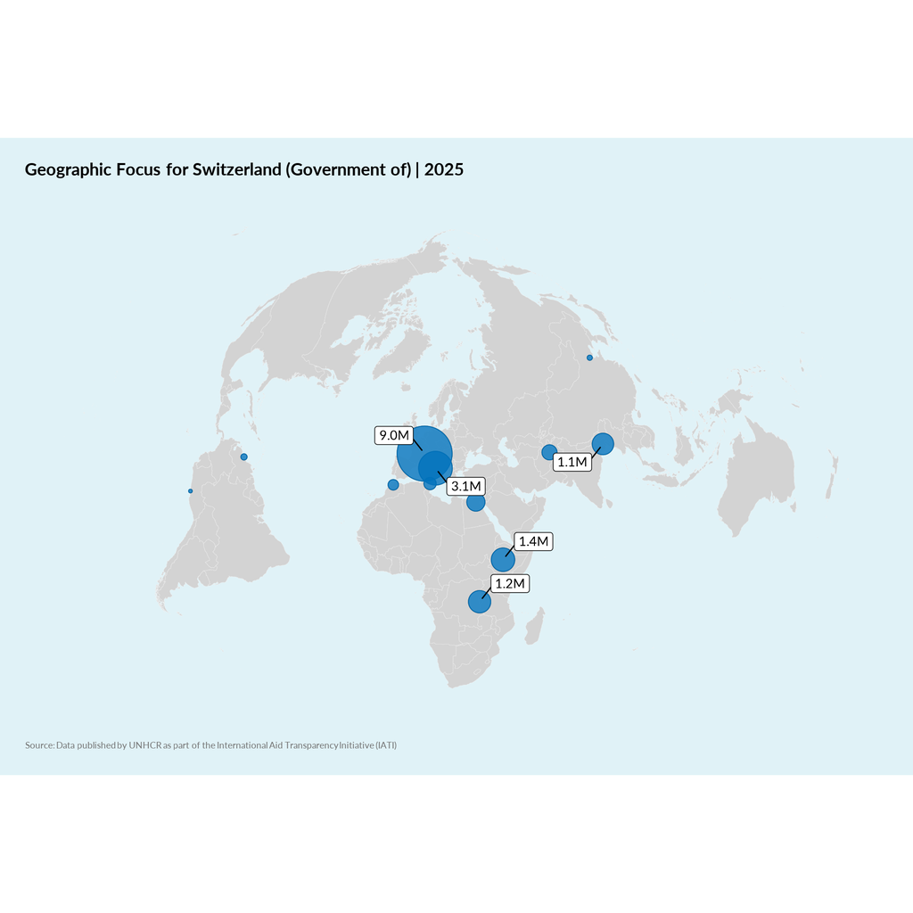

TRUE

## Earmarking Behavior

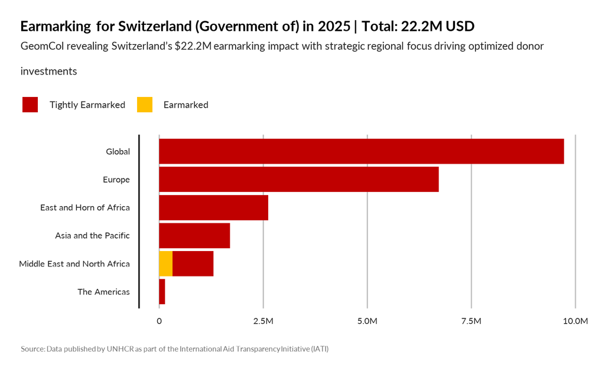

TRUE

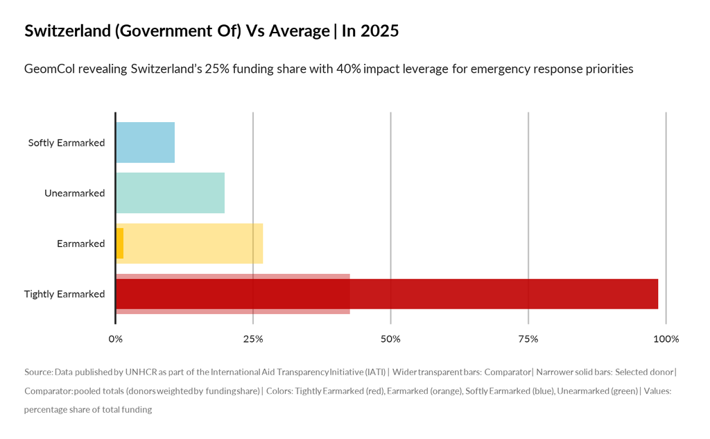

TRUE